# RITHEESH-STDS-Assignment 1

```python
import numpy as np
import pandas as pd
import scipy.stats as st
import statsmodels.stats as stm
import seaborn as sns
import matplotlib.pyplot as plt
```

```python
data=pd.read_excel(r"D:\PGCP-DSML RITHEESH V\Statistics\ASSIGNMENTS\Stats_assignment_1.xlsx")
```

```python
data.info
```

```
<bound method DataFrame.info of       customerID  gender  SeniorCitizen Partner Dependents  tenure  \
0     7590-VHVEG  Female              0     Yes         No       1
1     5575-GNVDE    Male              0      No         No      34
2     3668-QPYBK    Male              0      No         No       2
3     7795-CFOCW    Male              0      No         No      45
4     9237-HQITU  Female              0      No         No       2
...          ...     ...            ...     ...        ...     ...
7038  6840-RESVB    Male              0     Yes        Yes      24
7039  2234-XADUH  Female              0     Yes        Yes      72
7040  4801-JZAZL  Female              0     Yes        Yes      11
7041  8361-LTMKD    Male              1     Yes         No       4
7042  3186-AJIEK    Male              0      No         No      66

     PhoneService OnlineBackup TechSupport StreamingTV        Contract  \
0              No          Yes          No          No  Month-to-month
```

[output cut: 25 more lines]

CATEGORICAL DATA: 1.Customer ID 2.Gender 3.SeniorCitizen 4.Partner 5.Department 6.PhoneService 7.OnlineBackup 8.TechSuppot 9.Contract 10.Paperless 11.Payment 12.Churn NUMERICAL DATA: 1.Tenure 2.Monthly Charges

### ANALYSIS OF CATEGORICAL DATA

```python
data["gender"].value_counts()
```

```
Male      3555
Female    3488
Name: gender, dtype: int64
```

```python
round(data["gender"].value_counts(normalize=True)*100,0)
```

```
Male      50.0
Female    50.0
Name: gender, dtype: float64
```

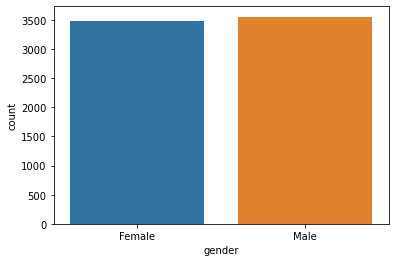

```python
sns.countplot(data.gender)
```

The Percentage of Male(50%) and Female(50%) customers are equal

```python
data["SeniorCitizen"].value_counts()
```

```
0    5901
1    1142
Name: SeniorCitizen, dtype: int64
```

```python
data["SeniorCitizen"].value_counts(normalize=True)
```

```
0    0.837853
1    0.162147
Name: SeniorCitizen, dtype: float64
```

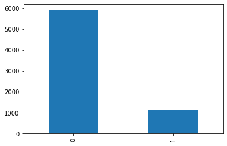

```python
data["SeniorCitizen"].value_counts().plot(kind="bar")
```

16% of people from the population are senior citizens

```python
print("male senior citizen",data[(data["gender"]=="Male")&(data["SeniorCitizen"]&[1])]["SeniorCitizen"].count())
print("female senior citizen",data[(data["gender"]=="Female")&(data["SeniorCitizen"]&[1])]["SeniorCitizen"].count())
```

```
male senior citizen 574
female senior citizen 568
```

```python
round(data.groupby("gender")["SeniorCitizen"].value_counts(100)*100,0)
```

```
gender  SeniorCitizen
Female  0                84.0
        1                16.0
Male    0                84.0
        1                16.0
Name: SeniorCitizen, dtype: float64
```

```python
data["SeniorCitizen"].value_counts()
```

```
0    5901
1    1142
Name: SeniorCitizen, dtype: int64
```

16% of male customers are seniorcitizen 16% of female customers are seniorcitizen

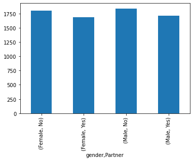

```python
data.groupby("gender")["Partner"].value_counts().plot(kind="bar")
```

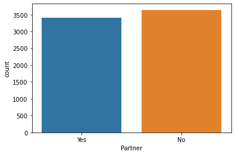

```python
sns.countplot(data.Partner)
```

```python
(data["PhoneService"].value_counts(normalize=True)*100)
```

```
Yes    90.316626
No      9.683374
Name: PhoneService, dtype: float64
```

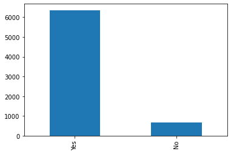

```python
data["PhoneService"].value_counts().plot(kind="bar")
```

90% of customers subscribed for phoneservices

```python
round(data["OnlineBackup"].value_counts(normalize=True)*100,0)
```

```
No                     44.0
Yes                    34.0
No internet service    22.0
Name: OnlineBackup, dtype: float64
```

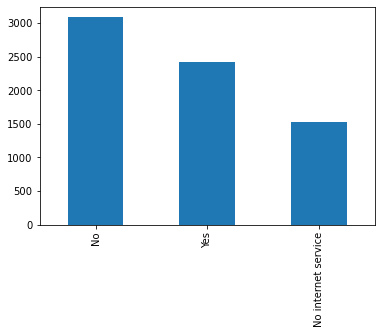

```python
data["OnlineBackup"].value_counts().plot(kind="bar")
```

```python
round(data["StreamingTV"].value_counts(normalize=True)*100,0)
```

```
No                     40.0
Yes                    38.0
No internet service    22.0
Name: StreamingTV, dtype: float64
```

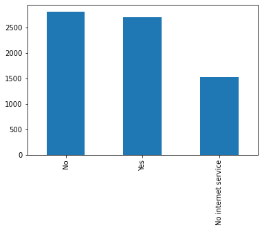

```python
data["StreamingTV"].value_counts().plot(kind="bar")
```

38% of people opted for TV Streaming service 40% of people did'nt opted for TV Streaming service 22% of people don't have internet connection

```python
round(data["Contract"].value_counts(normalize=True)*100,0)
```

```
Month-to-month    55.0
Two year          24.0
One year          21.0
Name: Contract, dtype: float64
```

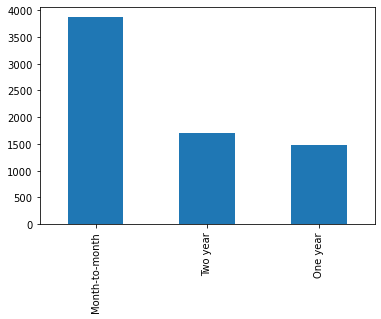

```python
data["Contract"].value_counts().plot(kind="bar")
```

55% of people make Month-to-Month contract and yearly contract percentages are low so we have revice the offers for yearly contract

```python
round(data["PaymentMethod"].value_counts(normalize=True)*100,0)
```

```
Electronic check             34.0
Mailed check                 23.0
Bank transfer (automatic)    22.0
Credit card (automatic)      22.0
Name: PaymentMethod, dtype: float64
```

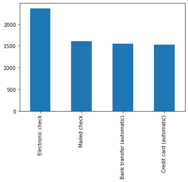

```python
data["PaymentMethod"].value_counts().plot(kind="bar")
```

### ANALYSIS OF NUMERICAL DATA

```python
from statsmodels.stats import descriptivestats
```

###### MEASURES OF LOCATION

```python
#first quartile (Q1)
data.tenure.quantile(.25)
```

```
9.0
```

```python
#second quartile (Q2)
data.tenure.quantile(.50)
```

```
29.0
```

```python
#third quartile (Q3)
data.tenure.quantile(.75)
```

```
55.0
```

###### MEASURES OF CENTRAL TENDENCY

```python
#MEAN
print("The mean of the tenure is ",data["tenure"].mean())
```

```
The mean of the tenure is  32.37114865824223
```

```python
#MEDIAN
print("The middle value of tenure is ",data["tenure"].median())
```

```
The middle value of tenure is  29.0
```

```python
#MODE
print("The most repeated value (mode) is ",data["tenure"].mode())
```

```
The most repeated value (mode) is  0    1
Name: tenure, dtype: int64
```

###### MEASURES OF DISPERSION

```python
#RANGE
range_tenure=data.tenure.max()-data.tenure.min()
range_tenure
```

```
72
```

```python
#Mean Absolute Deviation
mad_tenure=data.tenure.mad()
mad_tenure
```

```
21.8730899289692
```

```python
#Variance
msd_tenure=data.tenure.var()
msd_tenure
```

```
603.1681081237256
```

```python
#Standard deviation
std_tenure=data.tenure.std()
std_tenure
```

```
24.55948102309423
```

```python
# Coefficient of variation
cv_tenure=(data.tenure.std()/data.tenure.mean())*100
cv_tenure
```

```
75.86842617906603
```

The Coefficient of variation is above 60% (cv_tenure=75.8%) so the data is spread

###### MEASURES OF DISTRIBUTION SHAPE

```python
#skewness
data.tenure.skew()
```

```
0.2395397495619829
```

```python
#kurtosis
data.tenure.kurt()
```

```
-1.387371635971685
```

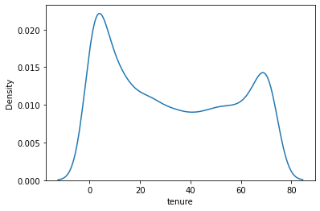

```python
sns.distplot(data.tenure,hist=False)
```

###### MEASURES OF LOCATION

```python
#For Monthly Charges
#first quartile (Q1)
data.MonthlyCharges.quantile(.25)
```

```
35.5
```

```python
#second quartile (Q2)
data.MonthlyCharges.quantile(.5)
```

```
70.35
```

```python
#Third Quartile (Q3)
data.MonthlyCharges.quantile(.75)
```

```
89.85
```

###### MEASURES OF CENTRAL TENDENCY

```python
#MEAN
print("The mean of the tenure is ",data["MonthlyCharges"].mean())
```

```
The mean of the tenure is  64.76169246059922
```

```python
#MEDIAN
print("The median of the tenure is ",data["MonthlyCharges"].median())
```

```
The median of the tenure is  70.35
```

```python
#MODE
print("The mode of the tenure is ",data["MonthlyCharges"].mode())
```

```
The mode of the tenure is  0    20.05
Name: MonthlyCharges, dtype: float64
```

###### MEASURES OF DISPERSION

```python
#RANGE
range_monthlycharges=data.MonthlyCharges.max()-data.MonthlyCharges.min()
range_monthlycharges
```

```
100.5
```

```python
#Mean Absolute Deviation
mad_monthlycharges=data.MonthlyCharges.mad()
mad_monthlycharges
```

```
26.222101512727452
```

```python
#Variance
msd_monthlycharges=data.MonthlyCharges.var()
msd_monthlycharges
```

```
905.4109343405128
```

```python
#Standard deviation
std_monthlycharges=data.MonthlyCharges.std()
std_monthlycharges
```

```
30.09004709767854
```

```python
#Coefficient of variation
cv_monthlycharges=(data.MonthlyCharges.std()/data.MonthlyCharges.mean())*100
cv_monthlycharges
```

```
46.462725037621915
```

###### MEASURES OF DISTRIBUTION SHAPE

```python
#skewness
data.MonthlyCharges.skew()
```

```
-0.22052443394398033
```

```python
#kurtosis
data.MonthlyCharges.kurt()
```

```
-1.2572596945495056
```

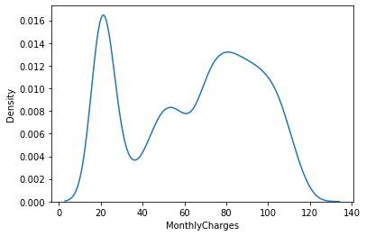

```python
sns.distplot(data.MonthlyCharges,hist=False)
```

###### MEASURES OF RELATIONSHIP

```python
data[["tenure","MonthlyCharges"]].corr()
```

|  | tenure | MonthlyCharges |
| --- | --- | --- |
| tenure | 1.0000 | 0.2479 |
| MonthlyCharges | 0.2479 | 1.0000 |

The correlation between tenure and MonthlyCharges is 0.2479 which is weak +ve

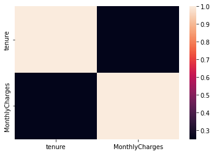

```python
sns.heatmap(data[["tenure","MonthlyCharges"]].corr())
```